# Stock Market Analysis

# Getting the stock data

Stock data can be obtained from [Yahoo Finance](http://finance.yahoo.com/), [Google Finance](http://finance.google.com/) or others. The **quantmod** package provides easy access to Yahoo and Google Finance data, along with other sources.

```r
# Getting quantmod
if(!require("quantmod")) {
    install.packages("quantmod", dependencies=TRUE)
    library(quantmod)
}
```

```
Learn from a quantmod author: https://www.datacamp.com/courses/importing-and-managing-financial-data-in-r
```

```r
if (!require("TTR")) {
  install.packages("TTR", dependencies=TRUE)
  library(TTR)
}
```

```r
start <- as.Date("2019-01-01")
end <- as.Date("2020-03-31")
```

We will use the **getSymbols** function from **quantmod** package and pass a string as a first argument to identify the desired ticker symbol and specify date range.

```r
getSymbols("MSFT", src="yahoo", from =  start, to = end, env=parent.frame(), auto.assign=TRUE)
```

[output not shown]

```
[1] "MSFT"
```

```r
class(MSFT)
```

```
[1] "xts" "zoo"
```

```r
head(MSFT)
```

```
           MSFT.Open MSFT.High MSFT.Low MSFT.Close MSFT.Volume MSFT.Adjusted
2019-01-02     99.55    101.75    98.94     101.12    35329300      99.37519
2019-01-03    100.10    100.19    97.20      97.40    42579100      95.71938
2019-01-04     99.72    102.51    98.93     101.93    44060600     100.17121
2019-01-07    101.64    103.27   100.98     102.06    35656100     100.29896
2019-01-08    103.04    103.97   101.71     102.80    31514400     101.02620
2019-01-09    103.86    104.88   103.24     104.27    32280800     102.47083
```

As you see above, getSymbols() created in the global environment an object called MSFT (named automatically after the ticker symbol of the security retrieved) that is of the **xts** class (which is also a **zoo**-class object).

# Visualizing stock data

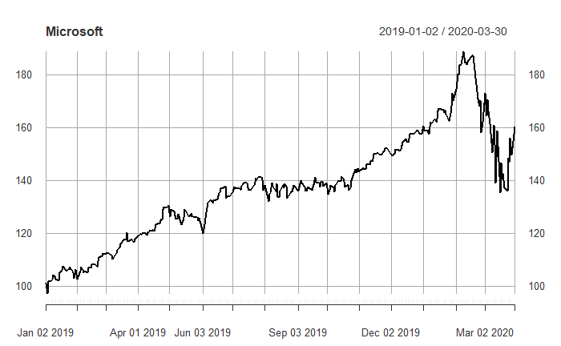

```r
plot(MSFT[, "MSFT.Close"], main = "Microsoft")
```

A linechart is fine, but there are at least four variables involved for each date (open, high, low, and close), and we would like to have some visual way to see all four variables that does not require plotting four separate lines. Financial data is often plotted with a **Japanese candlestick plot**, so named because it was first created by 18th century Japanese rice traders. Use the function candleChart() from **quantmod** to create such a chart.

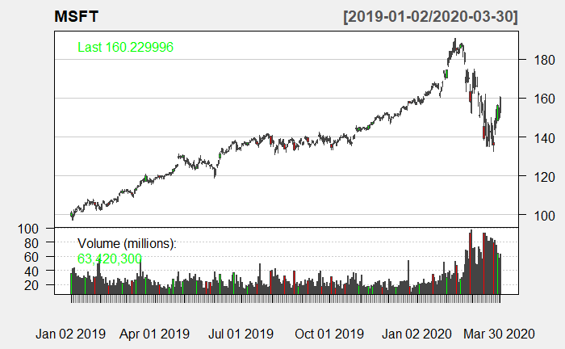

```r
candleChart(MSFT, up.col="green", dn.col="red", theme="white")
```

Let’s get other companies’ stock trend too.

```r
getSymbols(c("AAPL", "GOOG", "UBER", "LYFT", "AMZN", "FB", "TSLA", "NFLX", "INTC", "MDT", "JNJ", "AMD", "MU", "BAC", "BA", "DIS", "KO",
             "PEP", "WFC", "JPM"), src = "yahoo", from = start, to = end, env=parent.frame(), auto.assign=TRUE)
```

[output not shown]

```
 [1] "AAPL" "GOOG" "UBER" "LYFT" "AMZN" "FB"   "TSLA" "NFLX" "INTC" "MDT"  "JNJ"  "AMD"  "MU"   "BAC"  "BA"   "DIS"  "KO"   "PEP"
[19] "WFC"  "JPM"
```

Create an xts object (xts is loaded with quantmod) that contains closing prices for AAPL, MSFT, GOOG, TSLA and BA

```r
stocks <- as.xts(data.frame(AAPL = AAPL[, "AAPL.Close"], MSFT = MSFT[, "MSFT.Close"],
                            GOOG = GOOG[, "GOOG.Close"], BA = BA[, "BA.Close"], TSLA = TSLA[, "TSLA.Close"]))
head(stocks)
```

```
           AAPL.Close MSFT.Close GOOG.Close BA.Close TSLA.Close
2019-01-02     157.92     101.12    1045.85   323.81     310.12
2019-01-03     142.19      97.40    1016.06   310.90     300.36
2019-01-04     148.26     101.93    1070.71   327.08     317.69
2019-01-07     147.93     102.06    1068.39   328.11     334.96
2019-01-08     150.75     102.80    1076.28   340.53     335.35
2019-01-09     153.31     104.27    1074.66   343.83     338.53
```

Create a plot showing all series as lines; must use as.zoo to use the zoo method for plot, which allows for multiple series to be plotted on same plot

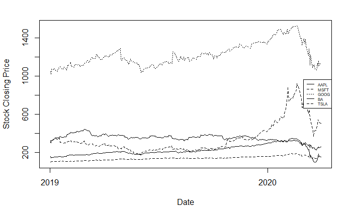

```r
plot(as.zoo(stocks), screens=1, lty=1:3, xlab="Date", ylab="Stock Closing Price")
legend("right", c("AAPL", "MSFT", "GOOG", "BA", "TSLA"), lty=1:3, cex=0.5)
```

Oops! While absolute price is important when trading, we are more concerned about the relative change of an asset rather than its absolute price. One solution would be to use two different scales when plotting the data; one scale will be used by Apple, Microsoft and Boeing and other by Tesla and Google.

```r
plot(as.zoo(stocks[, c("AAPL.Close", "MSFT.Close", "BA.Close")]), screens = 1, lty = 1:2,
    xlab = "Date", ylab = "Price")
par(new = TRUE)
```

```r
plot(as.zoo(stocks[, c("GOOG.Close", "TSLA.Close")]), screens = 1, lty = 3, xaxt = "n", yaxt = "n",
    xlab = "", ylab = "")
axis(4)
```

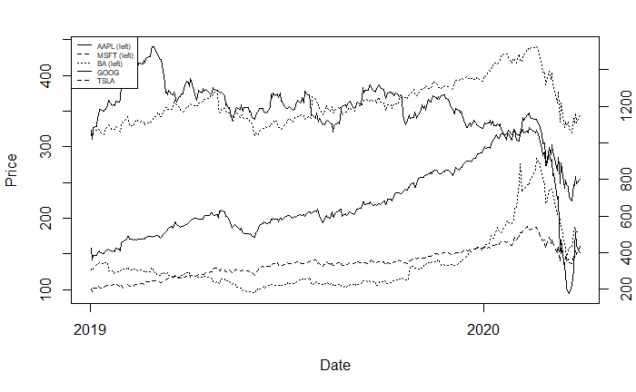

```r
mtext("Price", side = 4, line = 3)
legend("topleft", c("AAPL (left)", "MSFT (left)", "BA (left)", "GOOG", "TSLA"), lty = 1:3, cex = 0.5)
```

Well, this solution is little difficult and the visualization is also messy. For a little bit better solution, we can transform as follows:

```r
if (!require("magrittr")) {
    install.packages("magrittr")
    library(magrittr)
}
```

```r
stock_return = apply(stocks, 1, function(x) {x / stocks[1,]}) %>%
               t %>% as.xts
head(stock_return)
```

```
           AAPL.Close MSFT.Close GOOG.Close  BA.Close TSLA.Close
2019-01-02  1.0000000   1.000000   1.000000 1.0000000  1.0000000
2019-01-03  0.9003926   0.963212   0.971516 0.9601309  0.9685283
2019-01-04  0.9388298   1.008010   1.023770 1.0100985  1.0244099
2019-01-07  0.9367401   1.009296   1.021552 1.0132794  1.0800980
2019-01-08  0.9545973   1.016614   1.029096 1.0516352  1.0813556
2019-01-09  0.9708080   1.031151   1.027547 1.0618263  1.0916097
```

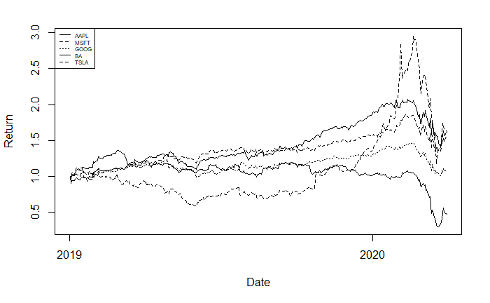

```r
plot(as.zoo(stock_return), screens = 1, lty = 1:3, xlab = "Date", ylab = "Return")
legend("topleft", c("AAPL", "MSFT", "GOOG", "BA", "TSLA"), lty = 1:3, cex = 0.5)
```

Taking the log of the change

```r
stock_change = stocks %>% log %>% diff
head(stock_change)
```

```
             AAPL.Close   MSFT.Close   GOOG.Close     BA.Close   TSLA.Close
2019-01-02           NA           NA           NA           NA           NA
2019-01-03 -0.104924358 -0.037481729 -0.028897528 -0.040685620 -0.031977598
2019-01-04  0.041803250  0.045460072  0.052389543  0.050733452  0.056094366
2019-01-07 -0.002228314  0.001274553 -0.002169087  0.003144123  0.052935024
2019-01-08  0.018883694  0.007224526  0.007357821  0.037154352  0.001163686
2019-01-09  0.016839167  0.014198278 -0.001506314  0.009644087  0.009437931
```

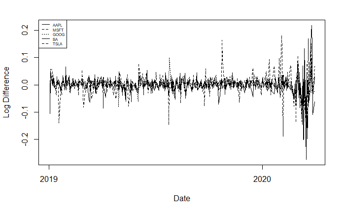

```r
plot(as.zoo(stock_change), screens = 1, lty = 1:3, xlab = "Date", ylab = "Log Difference")
legend("topleft", c("AAPL", "MSFT", "GOOG","BA", "TSLA"), lty = 1:3, cex = 0.5)
```

# Moving Averages

**quantmod** allows adding moving averages to charts via **addSMA()** function.

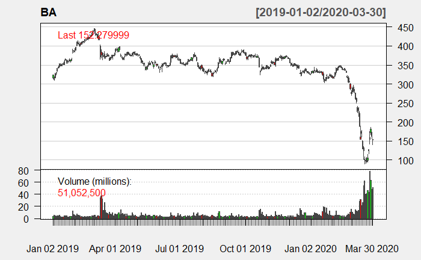

```r
candleChart(BA, up.col="green", dn.col="red", theme="white")
```

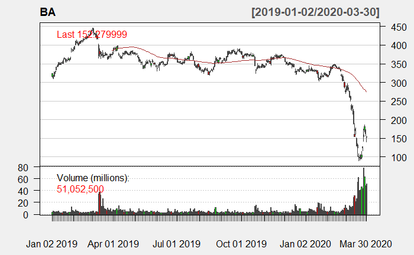

```r
addSMA(n=60)
```

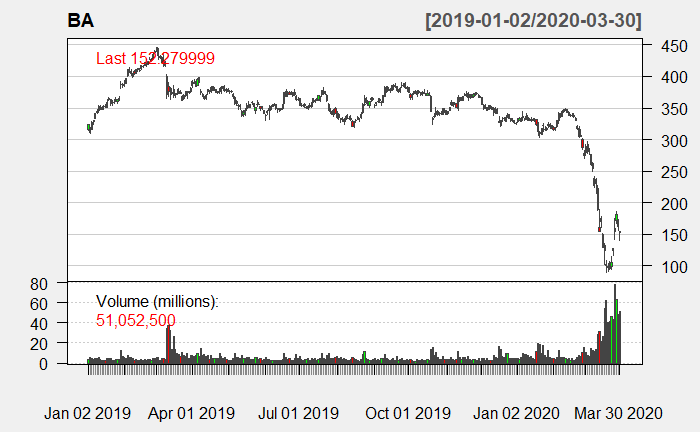

```r
candleChart(BA, up.col="green", dn.col="red", theme="white")
```

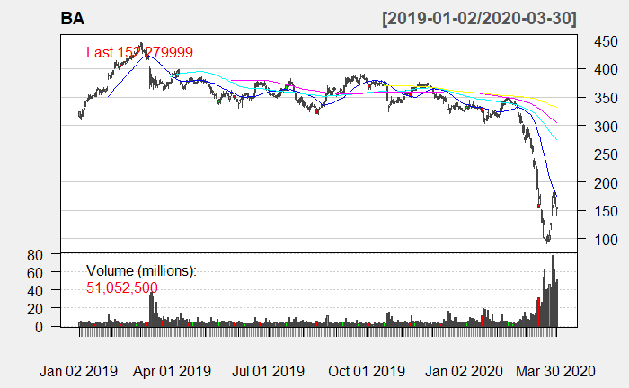

```r
addSMA(n = c(20, 60, 100, 200))
```